# Ethogram Data Collection 1 - Working (Success, Fail)

Marinara Marcato

# 1 Introduction

This document shows the data analysis carried out to investigate the association between ethogram scores filled out by two trainers and the dog’s working outcome. Statistical methods will be used to test the hypothesis that there is a relationship between ethogram scores at DC1 and working outcome (Success, Fail).

# 2 Data Exploration

The dataset comprised of the following types and number of variables. The original ethogram items contained ordinal and categorical variables. The score variables were numerical derived from the original ethogram items.

```
##
## categorical    comments        info     ordinal       score        time
##          17          16          17          53          42          25
##      unused
##          11
```

```
## [1] 17
```

All ordinal (N = 53) and categorical (N = 17) variables from the original ethogram items, score (N = 42) variables derived from the original ethogram items and demographical variables (N = 2) - namely, Sex and Breed - will be analysed.

## 2.1 Demographics

```
## Original dataset (dogs, variables):  98 132
```

```
##
##        GR GRxPoodle        LR       LRx     LRxGR
##         1         1        43        12        41
```

```
##
## Other    LR LRxGR
##     2    43    53
```

```
## Final dataset (dogs, variables):  98 132
```

```
##
## Success    Fail
##      77      21
```

```
##
##   Success      Fail
## 0.7857143 0.2142857
```

```
##
##  F  M
## 49 49
```

Calculate descriptive statistics for age at arrival at the training centre for formal training. Calculate descriptive statistics for age at assessment when the dogs performed the behaviour test at data collection 1, which should be around week 3 of formal training.

```
## Age at Arrival: Mean 15.3 Standard Deviation 2.04 Minimum: 12.3 Maximum: 21.9
```

```
## Age at Assessment: Mean 16.15 Standard Deviation 2.01 Minimum: 12.99 Maximum: 22.62
```

Calculate statistics of duration of training for the dogs that were withdrawn from training. Performing this behaviour test at the beginning on the training (Week 3) would allow assistance dog training organisations to understand which dog are more suitable and allow them to make informed decisions when analysing which dogs to keep for training considering the results of this objective assessment.

```
## [1] "Duration of Training in weeks"
```

```
##     Duration
##  Min.   : 1.143
##  1st Qu.: 8.857
##  Median :14.000
##  Mean   :15.000
##  3rd Qu.:16.857
##  Max.   :36.000
```

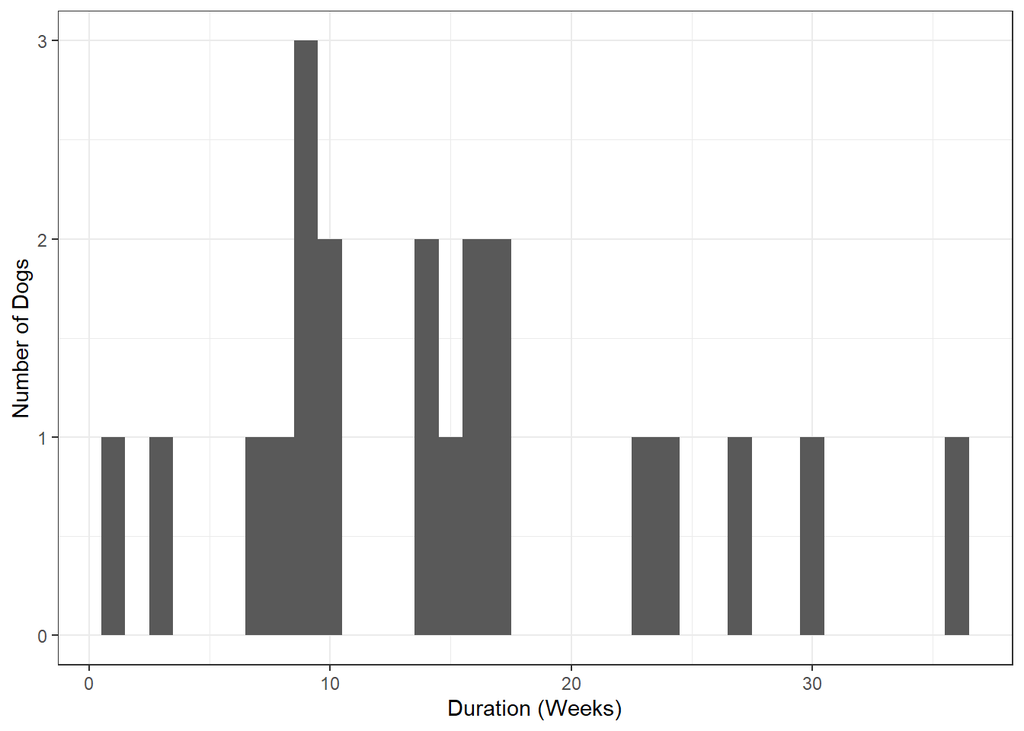

## 2.2 Descriptive Statistics

Calculate descriptive statistics for numerical and categorical variables.

```
##                                                      Min.   X1st.Qu.
## Data.Collection.Number                           1.000000   1.000000
## Duration                                         8.000000 146.250000
## Familiarisation.Response..Oriented.to.Handler.   1.000000   1.500000
## Familiarisation.Response..Exploration.           1.000000   4.000000
## Familiarisation.Response..Waiting.               1.000000   1.000000
## Call.Back.Response                               1.000000   1.000000
## Walking.Distractibility                          1.000000   1.000000
## Walking.Pull.on.leash                            1.000000   1.000000
## Walking.Pull.strength                            1.000000   1.000000
## Walking.Initiative                               1.000000   2.000000
## Standing.Response                                1.000000   2.000000
## Sitting.Response                                 1.000000   2.000000
## Lying.Response                                   1.000000   2.000000
## Lying.Settled                                    1.000000   1.000000
## Body.check.Table                                 1.000000   3.000000
## Body.check.Response                              1.000000   3.000000
## Distractions.First.Response..Teddy.              1.000000   3.000000
## Distractions.First.Response..Human.              2.000000   3.000000
## Distractions.First.Response..Car.                1.000000   2.250000
## Distractions.First.Response..Food.               1.000000   4.000000
## Distractions.Second.Response..Teddy.             1.000000   2.000000
## Distractions.Second.Response..Human.             1.000000   2.000000
## Distractions.Second.Response..Car.               1.000000   2.000000
## Distractions.Second.Response..Food.              1.000000   3.000000
## Distractions.Pull.on.leash                       1.000000   3.000000
## Distractions.Pull.strength                       1.000000   3.000000
## Distractions.Human                               3.000000   4.000000
## Kong.Presentation.Response                       1.000000   2.000000
## Kong.Interaction.Response.to.stimulus            1.000000   3.000000
## Kong.Interaction.Response.to.handler             1.000000   1.000000
## Kong.Interaction.Back                            1.000000   1.000000
## Kong.Return.Handler                              1.000000   2.000000
## Dog.Response                                     1.000000   4.000000
## Dog.Call.Back.Response                           1.000000   1.000000
## Crate.Entering                                   1.000000   1.000000
## Crate.Behaviours..Settled.                       1.000000   1.000000
## Crate.Behaviours..Sniffing.Exploring..           1.000000   2.000000
## Crate.Behaviours..Actively.Seeking.Attention.    1.000000   1.000000
## Crate.Behaviours..Digging.                       1.000000   1.000000
```

[output cut: 242 more lines]

```
## S.Crate.Stimulus_mean                            1.750000   3.250000    2
## S.Crate.Stimulus_prod                            4.000000 108.000000    0
## S.Crate.Handler_mean                             2.416667   4.000000    2
## S.Crate.Handler_prod                             9.000000  60.000000    0
## S.Petting.Stimulus.During_mean                   2.500000   4.000000    1
## S.Petting.Stimulus.During_prod                   4.000000  15.000000    0
## S.Petting.Engagement.During_mean                 2.500000   3.500000    1
## S.Petting.Engagement.During_prod                 4.000000  10.000000    0
## S.Petting.After_mean                             2.500000   3.500000    1
## S.Petting.After_prod                             4.000000  12.000000    0
## S.Isolation.Handler_mean                         3.000000   4.333333    1
## S.Isolation.Handler_prod                        15.750000  75.000000    0
## S.Isolation.Stimulus                             1.000000   3.000000    1
## S.Sociability_mean                               4.000000   5.333333    0
## S.Sociability_prod                              60.000000 150.000000    0
```

```
##                                                                  No Yes NA.s
## Body.check.General..Mouths.                                      94   3    1
## Body.check.General..Licks.                                       84  13    1
## Tea.Towel.First.Response..Indifferent.                           87  10    1
## Tea.Towel.First.Response..Change.from.Neutral.                   13  84    1
## Tea.Towel.First.Response..Turns.head.                            17  80    1
## Tea.Towel.First.Response..Attempts.to.Removes.towel.by.moving.   48  49    1
## Tea.Towel.First.Response..Attempts.to.Removes.towel.with.mouth.  52  45    1
## Tea.Towel.First.Response..Plays.                                 87  10    1
## Tea.Towel.Second.Response..Indifferent.                          71  24    3
## Tea.Towel.Second.Response..Turns.head.                           31  64    3
## Tea.Towel.Second.Response..Change.from.Neutral.                  26  69    3
## Tea.Towel.Second.Response..Attempts.to.Removes.towel.by.moving.  50  45    3
## Tea.Towel.Second.Response..Attempts.to.Removes.towel.with.mouth. 58  37    3
## Tea.Towel.Second.Response..Plays.                                82  13    3
## Crate.Urinating                                                  95   1    2
## Isolation.Urinating                                              97   1    1
```

## 2.3 Validity

Categorical: 1 out of 17 ethogram items, 1 out of 2 demographics variables (Sex and Breed).

```
## Categorical variable with 3 factors: Other LR LRxGR
```

```
##
## Call:
## glm(formula = Working ~ x, family = binomial(link = logit), data = dc_cat,
##     na.action = na.exclude)
##
## Deviance Residuals:
##     Min       1Q   Median       3Q      Max
## -1.1774  -0.8090  -0.5721  -0.5721   1.9447
##
## Coefficients:
##               Estimate Std. Error z value Pr(>|z|)
## (Intercept) -4.449e-14  1.414e+00   0.000    1.000
## xLR         -9.491e-01  1.455e+00  -0.653    0.514
## xLRxGR      -1.727e+00  1.465e+00  -1.179    0.239
##
## (Dispersion parameter for binomial family taken to be 1)
##
##     Null deviance: 101.838  on 97  degrees of freedom
## Residual deviance:  98.671  on 95  degrees of freedom
## AIC: 104.67
##
## Number of Fisher Scoring iterations: 4
```

```
## Categorical variable with 4 factors: Both Left None Righ
```

```
##
## Call:
## glm(formula = Working ~ x, family = binomial(link = logit), data = dc_cat,
##     na.action = na.exclude)
##
## Deviance Residuals:
##     Min       1Q   Median       3Q      Max
## -0.9331  -0.7981  -0.5035  -0.5035   2.0631
##
## Coefficients:
##             Estimate Std. Error z value Pr(>|z|)
## (Intercept)  -1.3863     0.7906  -1.754   0.0795 .
## xLeft         0.7802     0.9395   0.830   0.4063
## xNone        -0.6152     0.9231  -0.666   0.5051
## xRigh         0.4055     0.9242   0.439   0.6609
## ---
## Signif. codes:  0 '***' 0.001 '**' 0.01 '*' 0.05 '.' 0.1 ' ' 1
##
## (Dispersion parameter for binomial family taken to be 1)
##
##     Null deviance: 93.248  on 90  degrees of freedom
## Residual deviance: 88.526  on 87  degrees of freedom
##   (7 observations deleted due to missingness)
## AIC: 96.526
##
## Number of Fisher Scoring iterations: 4
```

Ordinal: 7 out of 53 ethogram items. Score: 10 out of 42 variables.

Save results from univariate analysis.

Converting logistic regression result to odds ratio and confidence intervals.

## 2.4 Feature Selection

Metholodogy adapted from Hosmer2013, pg 107 (GLOW study example).

### 2.4.1 Step 1: Univariate logistic regression model results.

Features which achieved P < 0.25 were selected for consideration to be included in the reduced feature set. Subsequentely, related variables were removed considering two cases: - Two scores: when both the mean and product scores were selected, the score with the highest p-value was removed. - Score and original items: when both the original item and the score derived from it were selected, the one with the highest p-value was removed.

**Variables with p < 0.25 (N = 28): original (N = 13), scores (N = 15) some are repeated**, **after removing related variables (N = 13): original (N = 9), scores (N = 4)**.

Variables whose logistic regression model resulted in p<0.15 when used to predict Working are shown. Positive estimates increase the probability of failure, while negative estimates decrease the probability of failure.

```
##                                               p_value_1
## S.Petting.Stimulus.During_mean                0.0176000
## Petting.Confidence.During                     0.0269000
## S.Distractions.Pull_mean                      0.0518000
## S.Petting.Stimulus.During_prod                0.0567000
## Crate.Behaviours..Sniffing.Exploring..        0.0577000
## S.Sociability_mean                            0.0591000
## S.Walking.Distractions.Pull_prod              0.0603000
## S.Distractions.Pull_prod                      0.0610000
## S.Sensitivity                                 0.0626000
## Body.check.Table                              0.0725000
## S.Crate.Stimulus_mean                         0.0846000
## Crate.Behaviours..Actively.Seeking.Attention. 0.1209000
## Petting.Handler.Stimulus                      0.1376000
## S.Sociability_prod                            0.1431000
## Tea.Towel.First.Response..Indifferent.        0.1490415
## Distractions.First.Response..Human.           0.1491000
```

### 2.4.2 Step 2: Correlation

0 features had correlation > 0.4.

```
## character(0)
```

[figure not shown]

## 2.5 Missing Data

DC1, missing values per column and per row. Very few data are missing considering the original items selected.

```
##                                       Working
##                                             0
##                      S.Distractions.Pull_mean
##                                             0
##                                 S.Sensitivity
##                                             0
##                         S.Crate.Stimulus_mean
##                                             2
##                S.Petting.Stimulus.During_mean
##                                             1
##        Tea.Towel.First.Response..Indifferent.
##                                             1
##           Distractions.First.Response..Human.
##                                             0
## Crate.Behaviours..Actively.Seeking.Attention.
##                                             3
```

```
## dc_row_nas
##  0  1  2
## 93  3  2
```

## 2.6 Visualization

```
## Plot these features manually:  Tea.Towel.First.Response..Indifferent.
```

```
## $x
## [1] "Tea Towel First Response  Indifferent "
##
## attr(,"class")
## [1] "labels"
```

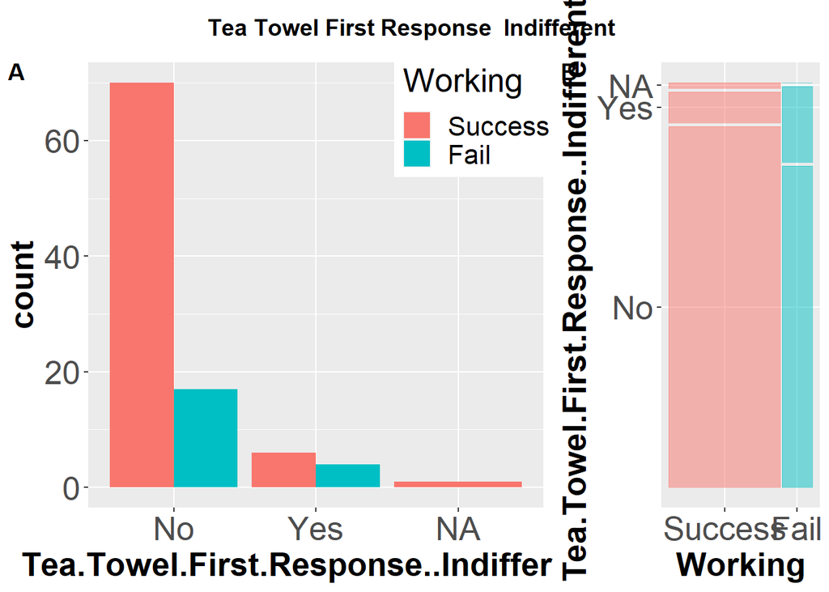

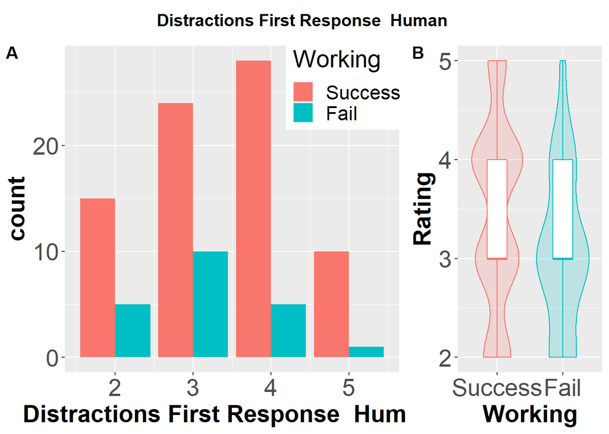

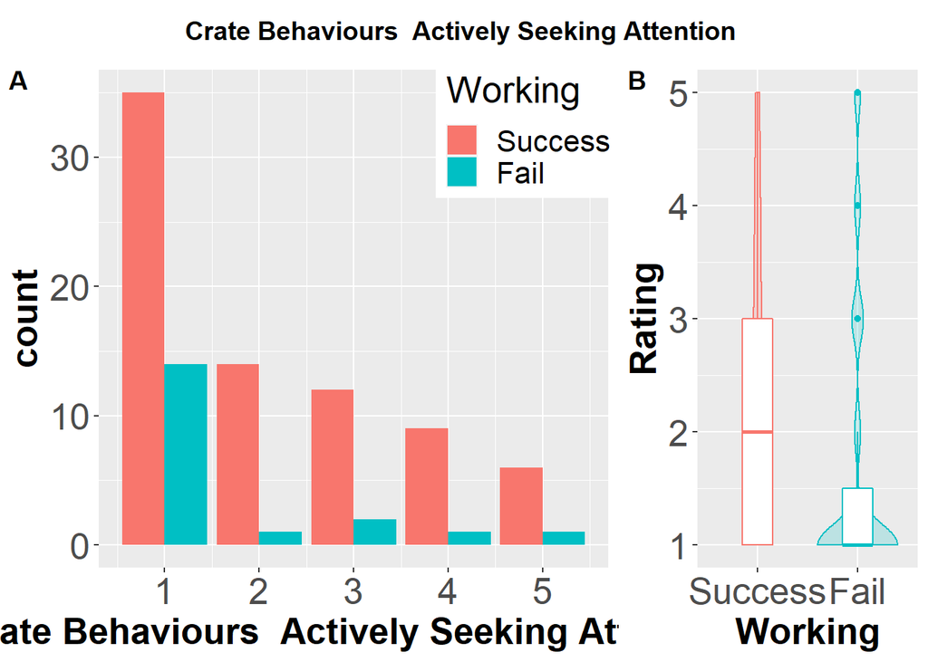

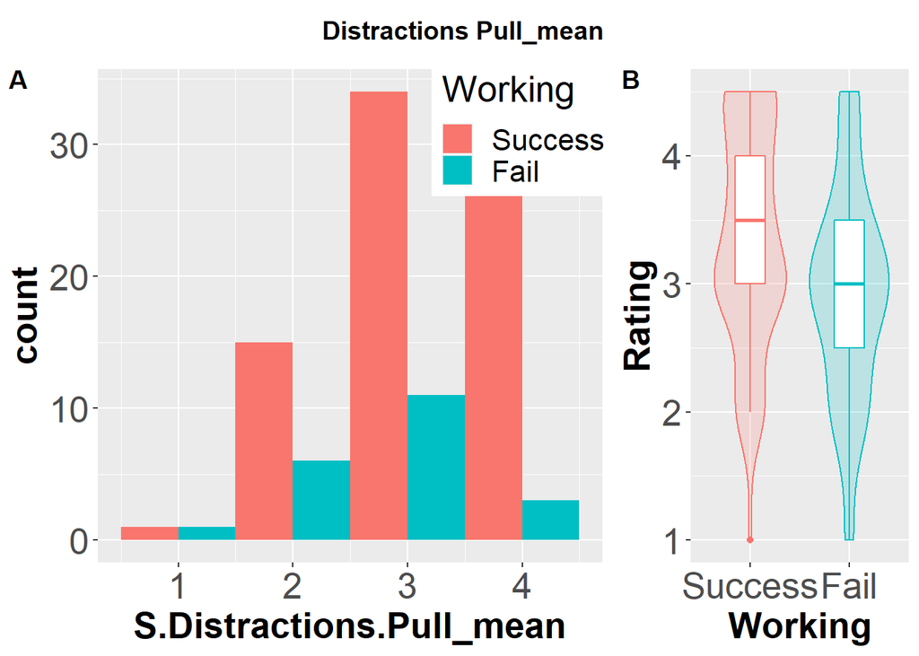

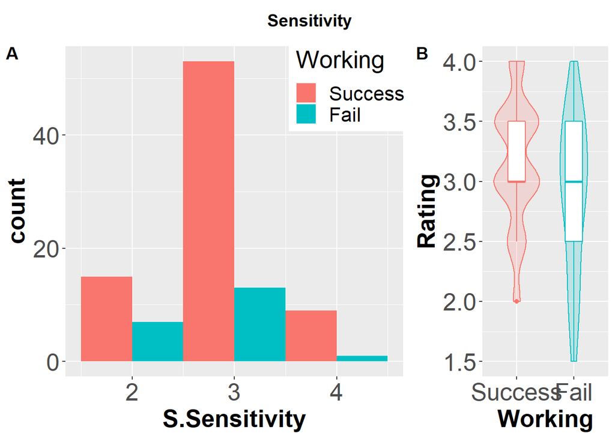

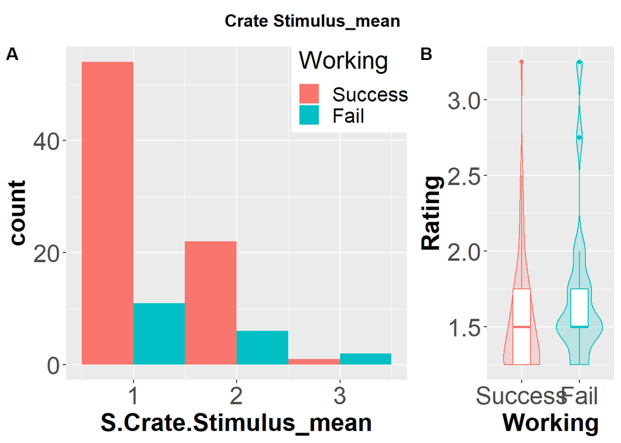

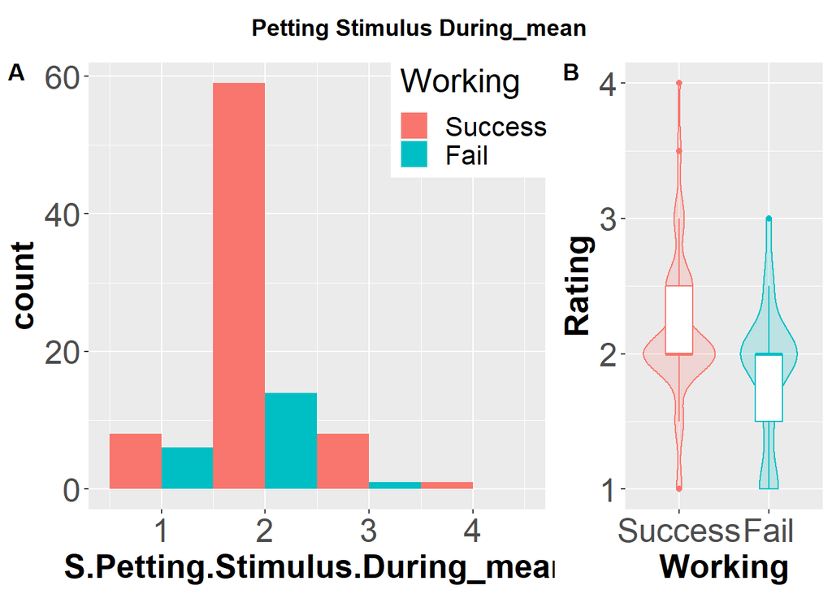

# 3 Multivariate Model

Preprocessing: Normalization + Imputation. Recursive Feature Elimination (RFE) + Multivariate Logistic Regression (LR). Optimising for F, sometimes recall, sometimes precision. Build model.

```
## [1] "Working"
## [2] "S.Distractions.Pull_mean"
## [3] "S.Sensitivity"
## [4] "S.Crate.Stimulus_mean"
## [5] "S.Petting.Stimulus.During_mean"
## [6] "Tea.Towel.First.Response..Indifferent."
## [7] "Distractions.First.Response..Human."
## [8] "Crate.Behaviours..Actively.Seeking.Attention."
```

```
## predicting second class: Fail Success
```

```
##
## Recursive feature selection
##
## Outer resampling method: Cross-Validated (98 fold)
##
## Resampling performance over subset size:
##
##  Variables AUC Precision  Recall   F AUCSD PrecisionSD RecallSD FSD
##          1 NaN    0.0000 0.00000 NaN    NA      0.0000   0.0000  NA
##          2 NaN    0.5000 0.14286   1    NA      0.5477   0.3586   0
##          3 NaN    0.2857 0.09524   1    NA      0.4880   0.3008   0
##          4 NaN    0.5000 0.23810   1    NA      0.5270   0.4364   0
##          5 NaN    0.3333 0.14286   1    NA      0.5000   0.3586   0
##          6 NaN    0.3636 0.19048   1    NA      0.5045   0.4024   0
##          7 NaN    0.4000 0.19048   1    NA      0.5164   0.4024   0
##  Num_Resamples Selected
##             98
##             98
##             98
##             98        *
##             98
##             98
##             98
##
## The top 4 variables (out of 4):
##    S.Distractions.Pull_mean, S.Petting.Stimulus.During_mean, S.Sensitivity, S.Crate.Stimulus_mean
```

```
##
## Call:
## glm(formula = Class ~ ., family = "binomial", data = tmp)
##
## Deviance Residuals:
##     Min       1Q   Median       3Q      Max
## -2.0629   0.2094   0.4607   0.5920   1.7403
##
## Coefficients:
##                                Estimate Std. Error z value Pr(>|z|)
## (Intercept)                      1.6696     0.3211   5.199 2.01e-07 ***
## S.Distractions.Pull_mean         0.9103     0.3151   2.889  0.00386 **
## S.Petting.Stimulus.During_mean   0.7712     0.3214   2.400  0.01641 *
## S.Sensitivity                    0.5662     0.2825   2.004  0.04507 *
## S.Crate.Stimulus_mean           -0.4111     0.2672  -1.539  0.12385
## ---
## Signif. codes:  0 '***' 0.001 '**' 0.01 '*' 0.05 '.' 0.1 ' ' 1
##
## (Dispersion parameter for binomial family taken to be 1)
##
##     Null deviance: 101.838  on 97  degrees of freedom
## Residual deviance:  81.839  on 93  degrees of freedom
## AIC: 91.839
##
## Number of Fisher Scoring iterations: 5
```

Model fitness with deviance analysis.

```
##
## deviance difference:  19.99895
```

```
##
## df difference:  4
```

```
##
## level of significance:  0.0004996376
```

```
##
## the model is a good fit:  TRUE
```

## 3.1 Performance

Performance metrics ROC and PR curves.

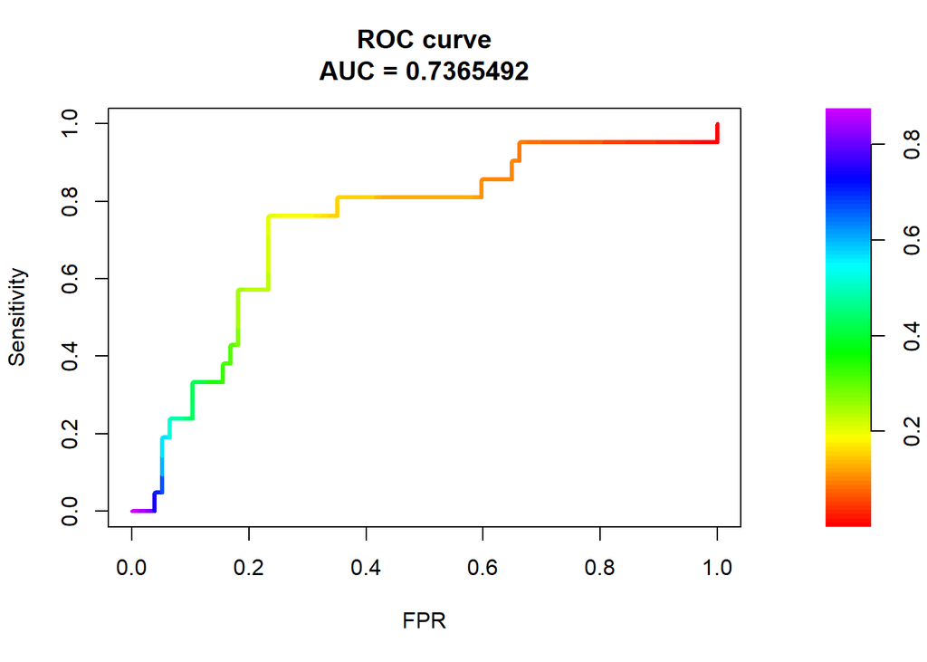

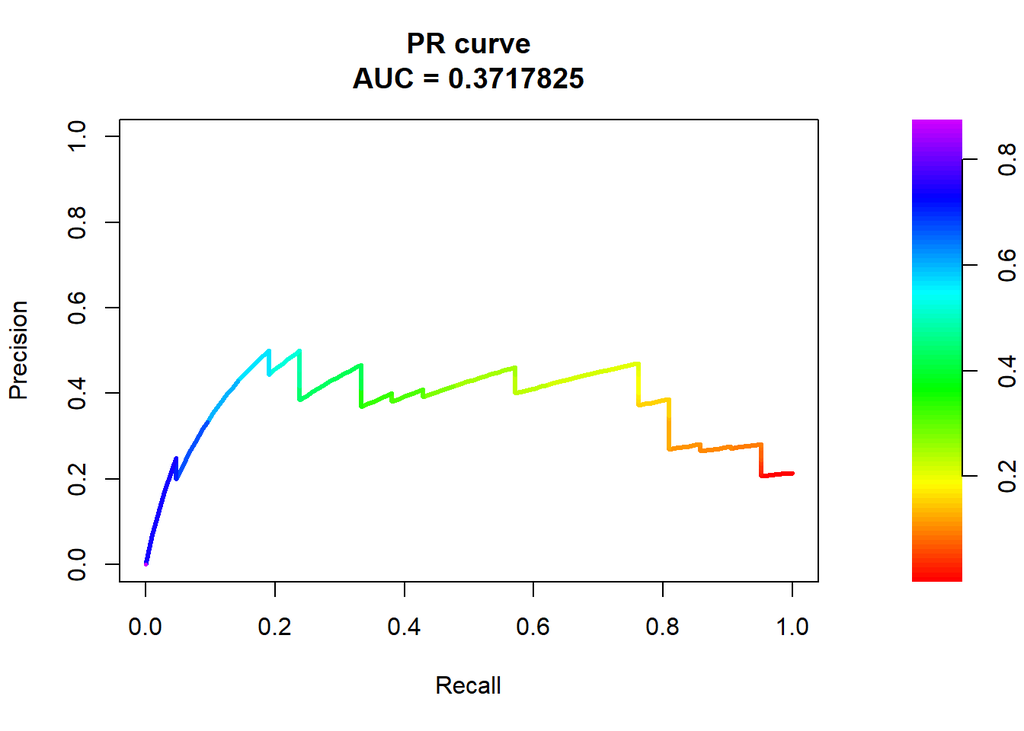

```
##          Accuracy   ROC    PR Precision Recall Sensitivity Specificity    F1
## Accuracy    0.786 0.737 0.372       0.5  0.238       0.238       0.935 0.323
##          Balanced.Accuracy
## Accuracy             0.587
```

Plot the logit.

```
## [1] "Probability predicted by the LR using PRQ data vs true Working"
```

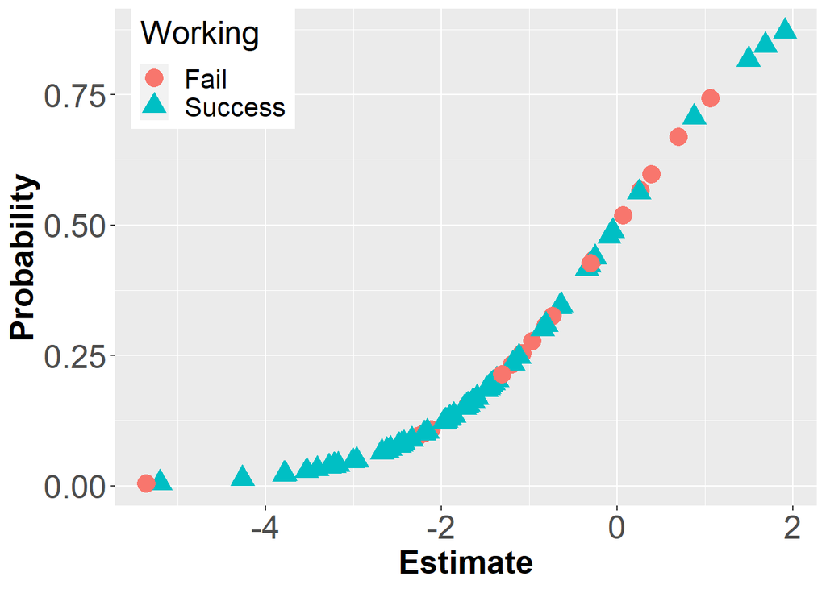

```
## [1] "Probability predicted by the LR using PRQ data vs true Status"
```

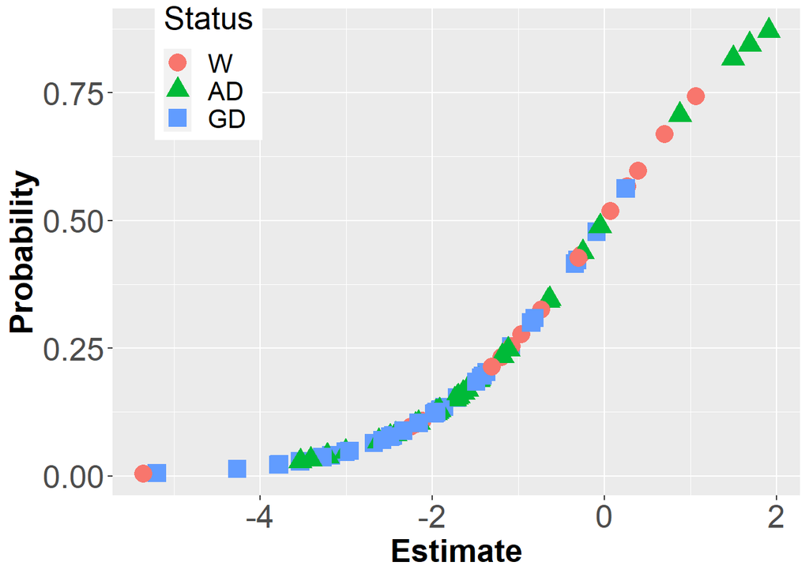

```
## [1] "Estimate and Probabilities per working outcome status"
```

```
## # A tibble: 3 × 2
##   Status  Mean
##   <fct>  <dbl>
## 1 W      -1.02
## 2 AD     -1.48
## 3 GD     -2.18
```

```
## # A tibble: 3 × 2
##   Status  Mean
##   <fct>  <dbl>
## 1 W      0.322
## 2 AD     0.237
## 3 GD     0.144
```

Names of the dogs that were false positives and false negatives.

```
## [1] "FALSE POSITIVE dogs predicted to fail, but succeed"
```

```
## [1] Josie  Harvey Gretel Molly  Harry
## 101 Levels: Clay Diva Dora Douglas Dugg Earl Ebbi Eddie Edrick Effie ... Zodiac
```

```
## [1] "FALSE NEGATIVE dogs predicted to succeed, but failed"
```

```
##  [1] Clay    Mac     Zeb     Douglas Zac     Idris   Eliza   Harold  Hayley
## [10] Herbie  Meeko   Zavier  Meg     Mara    Zaid    Emmy
## 101 Levels: Clay Diva Dora Douglas Dugg Earl Ebbi Eddie Edrick Effie ... Zodiac
```

## 3.2 Interpretation

Discuss model interpretation.

```
##                                  Estimate      P-value        OR      2.5 %
## (Intercept)                    -1.6695557 2.007018e-07 0.1883307 0.09420311
## S.Distractions.Pull_mean       -0.9103392 3.859470e-03 0.4023877 0.20682219
## S.Petting.Stimulus.During_mean -0.7712203 1.641435e-02 0.4624484 0.23516262
## S.Sensitivity                  -0.5661812 4.507027e-02 0.5676892 0.31388351
## S.Crate.Stimulus_mean           0.4110995 1.238505e-01 1.5084755 0.88394586
##                                   97.5 %
## (Intercept)                    0.3366666
## S.Distractions.Pull_mean       0.7224460
## S.Petting.Stimulus.During_mean 0.8392339
## S.Sensitivity                  0.9684586
## S.Crate.Stimulus_mean          2.5697144
```

# 4 Conclusion